# Clustering exploration for SCPCS000202

Maud PLASCHKA

2024-08-13

## Introduction

```r
subdiagnosis <- readr::read_tsv(
  file.path("..", "..", "..", "data", "current", params$scpca_project_id, "single_cell_metadata.tsv"),
  show_col_types = FALSE
) |>
  dplyr::filter(scpca_sample_id == params$sample_id) |>
  dplyr::pull(subdiagnosis) |>
  unique()
```

The aim is to explore the clustering and label transfers for the sample SCPCS000202. This sample has a(n) Favorable subdiagnosis.

In order to explore the clustering results, we look into some marker genes, pathways enrichment and label transfer.

This approach would provide us a rapid idea of the quality of the clustering:

- in the case each cluster do have a set of specific marker genes, we could expect each of the cluster to have at least a different phenotype,
- if marker genes are mostly shared between clusters, we might have over-clustered,
- if no marker genes are found, the quality of cells in the clusters might be impaired (high mitochondrial content? ribosomal content?)

### Packages

```r
library(Seurat)
library(sctransform)
library(SCpubr) # for plotting
library(tidyverse)
library(patchwork)
library(msigdbr)
library(enrichplot)
library(clusterProfiler)
library(org.Hs.eg.db)
library(ggalluvial)

options(future.globals.maxSize = 8912896000000)
set.seed(params$seed)
```

### Base directories

```r
# The base path for the OpenScPCA repository, found by its (hidden) .git directory
repository_base <- rprojroot::find_root(rprojroot::is_git_root)

# The current data directory, found within the repository base directory
data_dir <- file.path(repository_base, "data", "current", params$scpca_project_id)

# The path to this module
module_base <- file.path(repository_base, "analyses", "cell-type-wilms-tumor-06")
```

### Input files

In this notebook, we are working with the Wilms tumor sample defined in SCPCS000202 from the Wilms tumor dataset SCPCP000006. We work with the pre-processed and labeled `Seurat` object that is the output of `02b_label-transfer_fetal_kidney_reference_Stewart.Rmd` saved in the `results` directory.

```r
result_dir <- file.path(module_base, "results", params$sample_id)
```

To explore the clustering results, we look into some marker genes reported here:

```r
CellType_metadata <- read_csv(file.path(module_base, "marker-sets", "CellType_metadata.csv"))

DT::datatable(CellType_metadata,
  caption = ("CellType_metadata"),
  extensions = "Buttons",
  options = list(
    dom = "Bfrtip",
    buttons = c("csv", "excel")
  )
)
```

|  | gene_symbol | ENSEMBL_ID | cell_class | cell_type | DOI | comment |
| --- | --- | --- | --- | --- | --- | --- |
| 1 | WT1 | ENSG00000184937 | malignant | cancer_cell | 10.1242/dev.153163 | Tumor_suppressor_WT1_is_lost_in_some_WT_cells |
| 2 | IGF2 | ENSG00000167244 | malignant | cancer_cell | 10.1038/ng1293-408 |  |
| 3 | TP53 | ENSG00000141510 | malignant | anaplastic | 10.1158/1078-0432.CCR-16-0985 | Might_also_be_in_small_non_anaplastic_subset |
| 4 | MYCN | ENSG00000134323 | malignant | anaplastic | 10.18632/oncotarget.3377 | Also_in_non_anaplastic_poor_outcome |
| 5 | MAX | ENSG00000125952 | malignant | anaplastic | 10.1016/j.ccell.2015.01.002 | Also_in_non_anaplastic_poor_outcome |
| 6 | SIX1 | ENSG00000126778 | malignant | blastema | 10.1016/j.ccell.2015.01.002 |  |
| 7 | SIX2 | ENSG00000170577 | malignant | blastema | 10.1016/j.ccell.2015.01.002 |  |
| 8 | CITED1 | ENSG00000125931 | malignant | blastema | 10.1593/neo.07358 | Also_in_embryonic_kidney |
| 9 | PTPRC | ENSG00000081237 | immune |  | 10.1101/gr.273300.120 |  |
| 10 | CD68 | ENSG00000129226 | immune | myeloid | 10.1186/1746-1596-7-12 |  |

[output cut: 12 more lines]

### Output file

Reports will be saved in the `notebook` directory. The pre-processed and annotated `Seurat` object per samples are saved in the `result` folder.

## Functions

Here we defined function that will be used multiple time all along the notebook.

#### Visualize Seurat clusters and metadata

For a Seurat object `object`and a metadata `metadata`, the function `visualize_metadata` will plot `FeaturePlot` and `BarPlot`

- `object` is the Seurat object
- `metadata` the gene or quantitative value to be plotted
- `group.by` is the metadata used for grouping the violin plots

```r
visualize_metadata <- function(object, meta, group.by) {
  if (is.numeric(object@meta.data[, meta])) {
    d <- SCpubr::do_FeaturePlot(object,
      features = meta,
      pt.size = 0.2,
      legend.width = 0.5,
      legend.length = 5,
      legend.position = "right"
    ) + ggtitle(meta)
    b <- SCpubr::do_ViolinPlot(srat,
      features = meta,
      ncol = 1,
      group.by = group.by,
      legend.position = "none"
    )

    return(d + b + plot_layout(ncol = 2, widths = c(2, 4)))
  } else {
    d <- SCpubr::do_DimPlot(object, reduction = "umap", group.by = group.by, label = TRUE, repel = TRUE) + ggtitle(paste0(meta, " - umap")) + theme(text = element_text(size = 18))
    b <- SCpubr::do_BarPlot(
      sample = object,
      group.by = meta,
      split.by = group.by,
      position = "fill",
      font.size = 10,
      legend.ncol = 3
    ) +
      ggtitle("% cells") +
      xlab(print(group.by)) +
      theme(text = element_text(size = 18))
    return(d + b + plot_layout(ncol = 2, widths = c(2, 4)))
  }
}
```

#### Visualize Seurat clusters and markers genes

For a Seurat object `object`and a features `features`, the function `visualize_feature` will plot `FeaturePlot` and `ViolinPlot`

- `object` is the Seurat object
- `features` the gene or quantitative value to be plotted
- `group.by` is the metadata used for grouping the violin plots

```r
visualize_feature <- function(object, features, group.by = "seurat_clusters") {
  feature_symbol <- AnnotationDbi::select(org.Hs.eg.db,
    keys = features,
    columns = "SYMBOL",
    keytype = "ENSEMBL"
  )

  d <- SCpubr::do_FeaturePlot(object,
    features = feature_symbol$ENSEMBL,
    pt.size = 0.2,
    legend.width = 0.5,
    legend.length = 5,
    legend.position = "right"
  ) + ggtitle(feature_symbol$SYMBOL)
  b <- SCpubr::do_ViolinPlot(srat,
    features = feature_symbol$ENSEMBL,
    ncol = 1,
    group.by = group.by,
    legend.position = "none",
    assay = "SCT"
  ) + ylab(feature_symbol$SYMBOL)

  return(d + b + plot_layout(ncol = 2, widths = c(2, 4)))
}
```

#### Calculate `ModuleScore` from a `MSigDB` dataset

For a Seurat object `object`, the function `MSigDB_score` will calculate a score using `AddModuleScore()` function for a `MSigDB` gene set `gs_name` in the category `category`

- `object` is the Seurat object to calculate the score. Score will be added in the metadata of this object.
- `category` is a `MSigDB` collection (https://www.gsea-msigdb.org/gsea/msigdb/collections.jsp). values in `c("H", "C1", "C2", "C3", "C4", "C5", "C6", "C7", "C8")`
- `gs_name` is the name of a `MSigDB` gene set, e.g. `"HALLMARK_P53_PATHWAY"`
- `name` is the name of the module
- `nbins` is the number of bins for `AddModuleScore` to use. Its default value is 24, which matches Seurat’s default value.

```r
MSigDB_score <- function(object, category, gs_name, name, nbin = 24) {
  set <- msigdbr(species = "human", category = category)
  set_list <- set %>%
    dplyr::filter(gs_name == gs_name) %>%
    dplyr::distinct(gs_name, gene_symbol, human_ensembl_gene) %>%
    as.data.frame()
  set_list <- list(set_list$human_ensembl_gene)
  suppressWarnings({
    # AddModuleScore is known to throw an error when there are too few cells, e.g.:
    # https://github.com/satijalab/seurat/issues/5814 (the source of this error is the call to AddModuleScore)
    # When we have fewer than ~500 cells, this error will occur. To avoid this, we override the `ctrl` (default 100) parameter to a lower value (15)
    if (ncol(object) <= 500) {
      object <- AddModuleScore(object, features = set_list, name = name, nbin = nbin, ctrl = 15)
    } else {
      object <- AddModuleScore(object, features = set_list, name = name, nbin = nbin)
    }
  })
  return(object)
}
```

#### Enrichment analysis

`Enrichment_plot`aim to perform enrichment of the marker genes for each of the Seurat clusters and summarize the results in a `dotplot`.

- `category` is the `MSigDB` category or collection to be used values in `c("H", "C1", "C2", "C3", "C4", "C5", "C6", "C7", "C8")`
- `signatures` is a list of marker genes per cluster
- `background`is the universe used for enrichment

```r
Enrichment_plot <- function(category, signatures, background) {
  ## define genesets
  tryCatch(
    expr = {
      gene_set <- msigdbr(species = "human", category = category)
      msigdbr_set <- gene_set %>%
        dplyr::distinct(gs_name, ensembl_gene) %>%
        as.data.frame()
      cclust <- compareCluster(
        geneCluster = signatures,
        fun = enricher,
        TERM2GENE = msigdbr_set,
        universe = background
      )
      d <- dotplot(cclust, showCategory = 15) + scale_y_discrete(labels = function(x) str_wrap(x, width = 40))
      return(d)
    },
    error = function(e) {
      print("No enrichment")
    }
  )
}
```

#### do_Table_Heatmap

`do_Table_Heatmap` shows heatmap of counts of cells for combinations of two metadata variables

- `data` Seurat object
- `first_group` is the name of the first metadata to group the cells
- `last_group` is the name of the second metadata to group the cells

```r
do_Table_Heatmap <- function(data, first_group, last_group) {
  df <- data@meta.data %>%
    mutate_if(sapply(data@meta.data, is.character), as.factor) %>%
    group_by(!!sym(first_group), !!sym(last_group)) %>%
    summarise(Nb = log(n()))

  p <- ggplot(df, aes(x = !!sym(first_group), y = !!sym(last_group), fill = Nb)) +
    geom_tile() +
    scale_fill_viridis_c() +
    theme_bw() +
    theme(text = element_text(size = 20)) +
    theme(axis.text.x = element_text(angle = 90, vjust = 0.5, hjust = 1)) +
    guides(fill = guide_legend(title = " Number of \n cells (log)"))

  return(p)
}
```

## Analysis

### Load the pre-processed `Seurat` object

```r
# open the processed rds object
srat <- readRDS(file.path(result_dir, paste0("02b-fetal_kidney_label-transfer_", params$sample_id, ".Rds")))
DefaultAssay(srat) <- "SCT"

# Add number of bins to use with Seurat::AddModuleScore().
# One sample in this project fails with the default number of bins, so we need to override it
if (params$testing) {
  seurat_nbins <- 5
} else if (params$sample_id == "SCPCS000197") {
  seurat_nbins <- 23 # default is 24, so this is very close
} else {
  seurat_nbins <- 24
}
```

### Visualize Seurat clusters

We expect up to 5 set of clusters:

- blastema cancer cells
- epithelium cancer and/or normal cells
- stroma cancer and/or normal cells
- immune cells
- endothelial cells

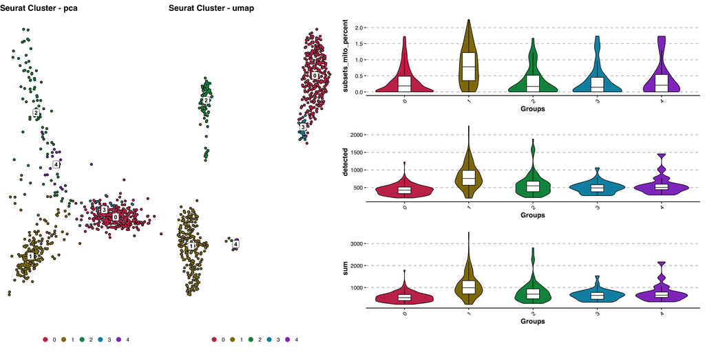

```r
d1 <- SCpubr::do_DimPlot(srat, reduction = "pca", group.by = "seurat_clusters", label = TRUE) + ggtitle("Seurat Cluster - pca")
d2 <- SCpubr::do_DimPlot(srat, reduction = "umap", group.by = "seurat_clusters", label = TRUE) + ggtitle("Seurat Cluster - umap")
v1 <- SCpubr::do_ViolinPlot(srat, features = c("subsets_mito_percent"), ncol = 1, group.by = "seurat_clusters", legend.position = "none")
v2 <- SCpubr::do_ViolinPlot(srat, features = c("detected"), ncol = 1, group.by = "seurat_clusters", legend.position = "none")
v3 <- SCpubr::do_ViolinPlot(srat, features = c("sum"), ncol = 1, group.by = "seurat_clusters", legend.position = "none")

d1 + d2 + (v1 + v2 + v3 + plot_layout(ncol = 1)) + plot_layout(ncol = 3, widths = c(2, 2, 4))
```

### Cell cycle information

```r
s.genes <- srat@assays$RNA@meta.data$gene_ids[srat@assays$RNA@meta.data$gene_symbol %in% cc.genes$s.genes]
g2m.genes <- srat@assays$RNA@meta.data$gene_ids[srat@assays$RNA@meta.data$gene_symbol %in% cc.genes$g2m.genes]

# CellCycleSorting is known to throw an error when there are too few cells, e.g.:
# https://github.com/satijalab/seurat/issues/5814
# When we have fewer than ~500 cells, this error will occur. To avoid this, we override the `ctrl` (default 100) parameter to a lower value (15)
if (ncol(srat) <= 500) {
  srat <- CellCycleScoring(srat, s.features = s.genes, g2m.features = g2m.genes, set.ident = FALSE, nbin = seurat_nbins, ctrl = 15)
} else {
  srat <- CellCycleScoring(srat, s.features = s.genes, g2m.features = g2m.genes, set.ident = FALSE, nbin = seurat_nbins)
}
```

```
## [1] "seurat_clusters"
```

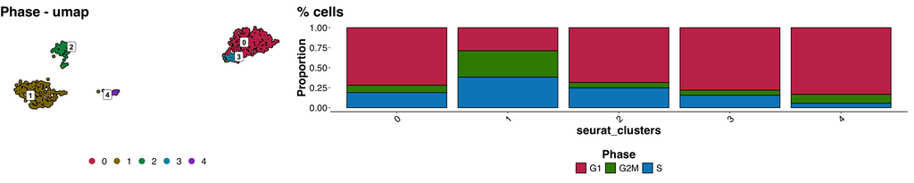

```r
visualize_metadata(srat, meta = "Phase", group.by = "seurat_clusters")
```

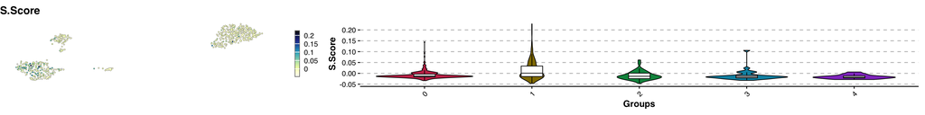

```r
visualize_metadata(srat, meta = "S.Score", group.by = "seurat_clusters")
```

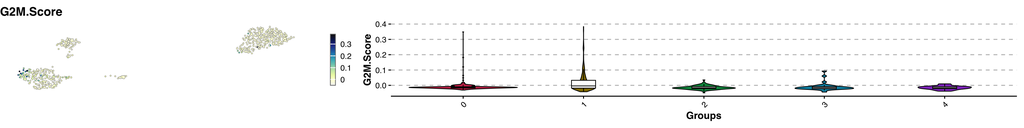

```r
visualize_metadata(srat, meta = "G2M.Score", group.by = "seurat_clusters")
```

### Look at specific genes

Here, we open the table of marker genes `marker-sets/CellType_metadata.csv`. Note: we do not expect to have a clear and nice pattern of expression for all of the following markers in every tumor. This is just ti get a few idea.

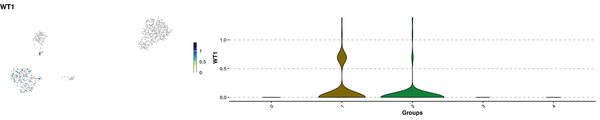

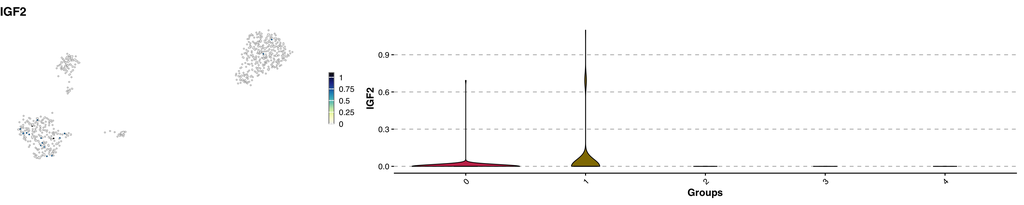

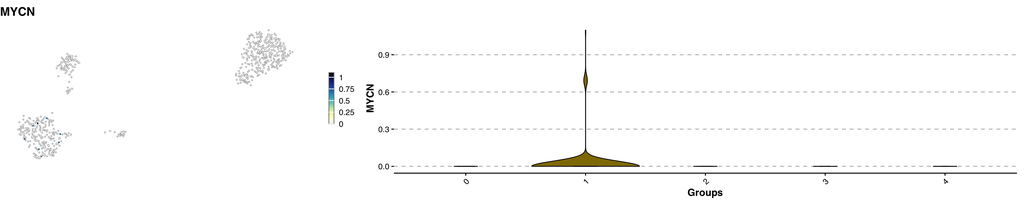

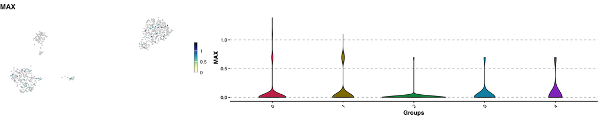

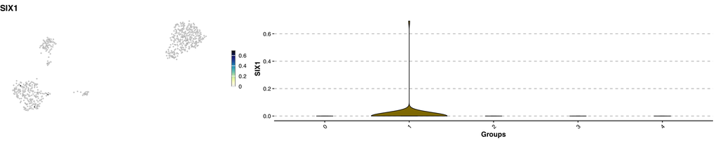

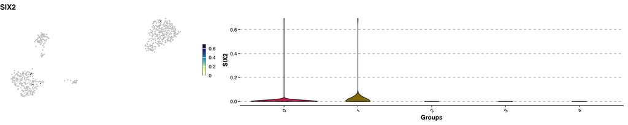

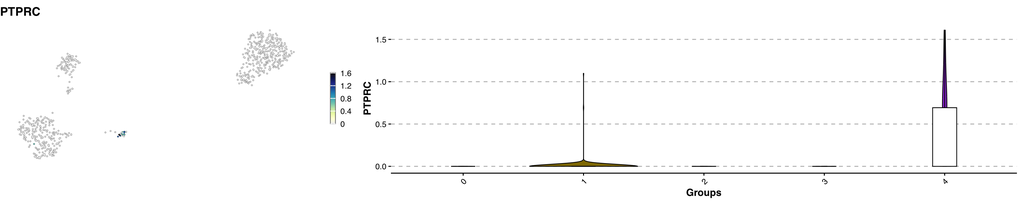

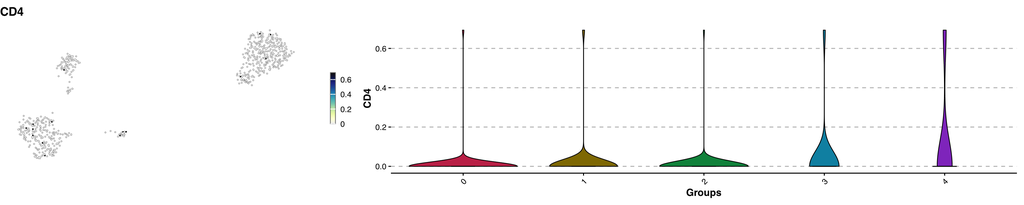

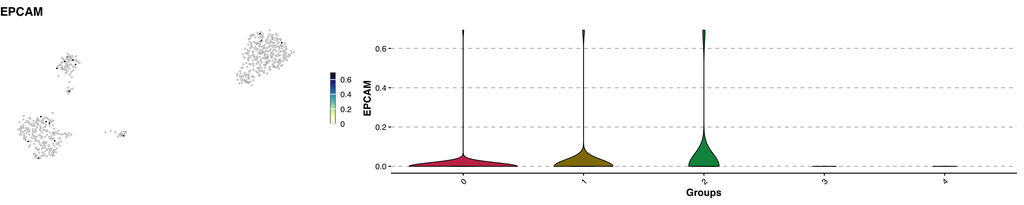

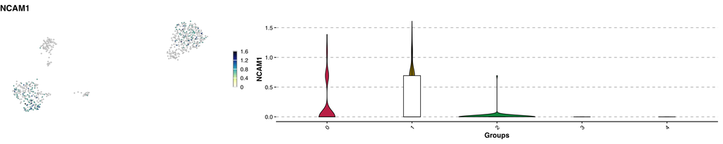

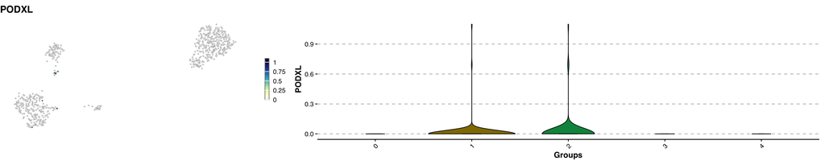

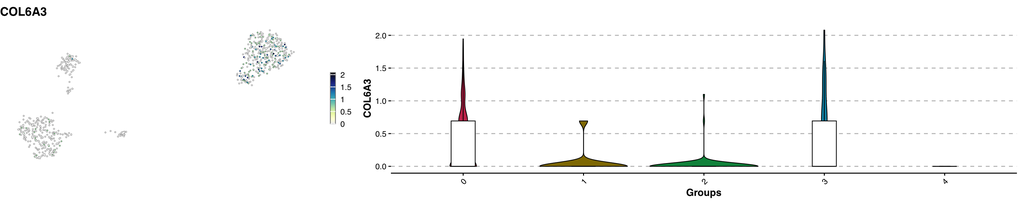

[1 more figures not shown]

```r
for (feature in CellType_metadata$ENSEMBL_ID[CellType_metadata$ENSEMBL_ID %in% rownames(srat@assays$SCT)]) {
  print(visualize_feature(srat, features = feature, group.by = "seurat_clusters"))
}
```

### Look at specific pathways

#### `TP53` pathway

here we will calculate a `TP53` score using `AddModuleScore` and the genes of the HALLMARK_P53_PATHWAY gene set.

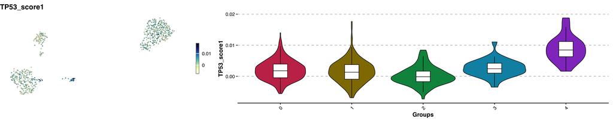

```r
srat <- MSigDB_score(object = srat, category = "H", gs_name = "HALLMARK_P53_PATHWAY", name = "TP53_score", nbin = seurat_nbins)
visualize_metadata(srat, meta = "TP53_score1", group.by = "seurat_clusters")
```

#### DNA repair pathway

here we will calculate a DNA_repair score using `AddModuleScore` and the genes of the HALLMARK_DNA_REPAIR gene set.

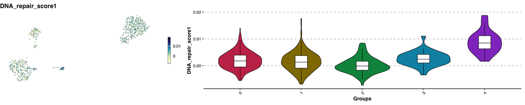

```r
srat <- MSigDB_score(object = srat, category = "H", gs_name = "HALLMARK_DNA_REPAIR", name = "DNA_repair_score", nbin = seurat_nbins)
visualize_metadata(srat, meta = "DNA_repair_score1", group.by = "seurat_clusters")
```

Note: Chemo-treated samples should have higher DNA-damage scores.

#### `DROSHA` target genes

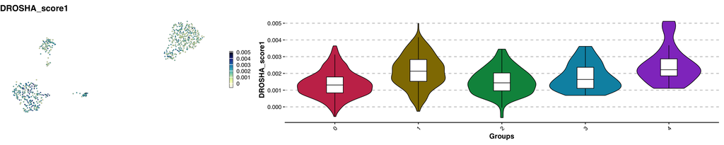

```r
srat <- MSigDB_score(object = srat, category = "C3", gs_name = "DROSHA_TARGET_GENES", name = "DROSHA_score", nbin = seurat_nbins)
visualize_metadata(srat, meta = "DROSHA_score1", group.by = "seurat_clusters")
```

#### `DICER1` target genes

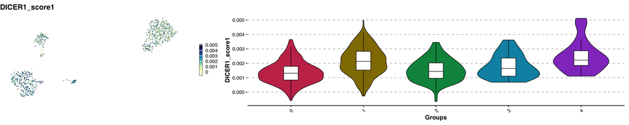

```r
srat <- MSigDB_score(object = srat, category = "C3", gs_name = "DICER1_TARGET_GENES", name = "DICER1_score", nbin = seurat_nbins)
visualize_metadata(srat, meta = "DICER1_score1", group.by = "seurat_clusters")
```

### Find marker genes for each of the Seurat clusters

In addition to the list of known marker genes, we used an unbiased approach to find transcripts that characterized the different clusters.

We run `DElegate::FindAllMarkers2` to find markers of the different clusters and manually check if they do make sense. `DElegate::FindAllMarkers2` is an improved version of `Seurat::FindAllMarkers` based on pseudobulk differential expression method. Please check the preprint from Hafemeister: https://www.biorxiv.org/content/10.1101/2023.03.28.534443v1 and tool described here: https://github.com/cancerbits/DElegate

Of note, we won’t use it for annotation, this is just here to get an idea!

```r
# this chunk is not run in testing (CI) since there are generally too few clusters for the method to work
feature_conversion <- srat@assays$RNA@meta.data
de_results <- DElegate::FindAllMarkers2(srat, group_column = "seurat_clusters")
# filter the most relevant markers
s.markers <- de_results[de_results$padj < params$padj_thershold & de_results$log_fc > params$lfc_threshold & de_results$rate1 > params$rate1_threshold, ]
# add gene symbol for easiest interpretation of the result
s.markers$gene_ids <- s.markers$feature
s.markers <- left_join(s.markers, feature_conversion, by = c("gene_ids"))
stopifnot(
  "Error joining gene ids and feature names" = identical(s.markers$feature, s.markers$gene_ids)
)
```

```r
DT::datatable(s.markers,
  caption = ("marker genes"),
  extensions = "Buttons",
  options = list(
    dom = "Bfrtip",
    buttons = c("csv", "excel")
  )
)
```

|  | feature | ave_expr | log_fc | stat | pvalue | padj | rate1 | rate2 | group1 | feature_rank | gene_ids | gene_symbol | mean | detected |
| --- | --- | --- | --- | --- | --- | --- | --- | --- | --- | --- | --- | --- | --- | --- |
| 1 | ENSG00000067715 | 11.37592312048328 | 3.056747551203141 | 508.3335381821282 | 5.851360417874817e-13 | 8.074788687081696e-11 | 0.7823343848580442 | 0.2753246753246753 | 0 | 1 | ENSG00000067715 | SYT1 | 1.648148148148148 | 50.42735042735043 |
| 2 | ENSG00000169744 | 10.49193005005845 | 3.499024814113231 | 499.2040522880426 | 6.690826056520835e-13 | 8.074788687081696e-11 | 0.7350157728706624 | 0.1506493506493506 | 0 | 3 | ENSG00000169744 | LDB2 | 0.9031339031339032 | 41.45299145299145 |
| 3 | ENSG00000173077 | 10.131463439121 | 3.761424539828746 | 485.8420355651672 | 8.180168509422253e-13 | 8.074788687081696e-11 | 0.5867507886435331 | 0.09350649350649351 | 0 | 4 | ENSG00000173077 | DELEC1 | 0.7065527065527065 | 31.62393162393162 |
| 4 | ENSG00000187720 | 11.12023849157945 | 3.807293917355781 | 477.6125555410855 | 9.217795304887782e-13 | 8.074788687081696e-11 | 0.7854889589905363 | 0.1766233766233766 | 0 | 5 | ENSG00000187720 | THSD4 | 1.353276353276353 | 45.15669515669516 |
| 5 | ENSG00000275443 | 11.44340993345876 | 2.226816641229049 | 439.5420595015907 | 1.681530948092251e-12 | 1.185872088873384e-10 | 0.8706624605678234 | 0.4675324675324675 | 0 | 6 | ENSG00000275443 |  | 1.797720797720798 | 64.95726495726495 |
| 6 | ENSG00000172572 | 10.86869352957471 | 3.024143434560874 | 432.3875851961764 | 1.895229365779381e-12 | 1.185872088873384e-10 | 0.7160883280757098 | 0.187012987012987 | 0 | 7 | ENSG00000172572 | PDE3A | 1.176638176638177 | 42.5925925925926 |
| 7 | ENSG00000247809 | 11.20746631494971 | 2.128205009344203 | 393.7229698450979 | 3.728860010117116e-12 | 2.041550855539121e-10 | 0.8107255520504731 | 0.4675324675324675 | 0 | 8 | ENSG00000247809 | NR2F2-AS1 | 1.544159544159544 | 62.25071225071225 |
| 8 | ENSG00000169554 | 9.719561158532313 | 3.379707330816851 | 380.9122107429094 | 4.763810666422124e-12 | 2.318387857658767e-10 | 0.5962145110410094 | 0.09350649350649351 | 0 | 9 | ENSG00000169554 | ZEB2 | 0.5441595441595442 | 32.05128205128205 |
| 9 | ENSG00000215386 | 10.13572102376659 | 2.908843928677483 | 338.5895804630697 | 1.106874781806103e-11 | 4.745850704854445e-10 | 0.5867507886435331 | 0.1766233766233766 | 0 | 10 | ENSG00000215386 | MIR99AHG | 0.7279202279202279 | 36.18233618233619 |
| 10 | ENSG00000271774 | 10.20570847274547 | 2.839439384287501 | 331.0648055928281 | 1.300233069823135e-11 | 4.745850704854445e-10 | 0.5678233438485805 | 0.1766233766233766 | 0 | 12 | ENSG00000271774 |  | 0.7635327635327636 | 35.32763532763533 |

[output cut: 69 more lines]

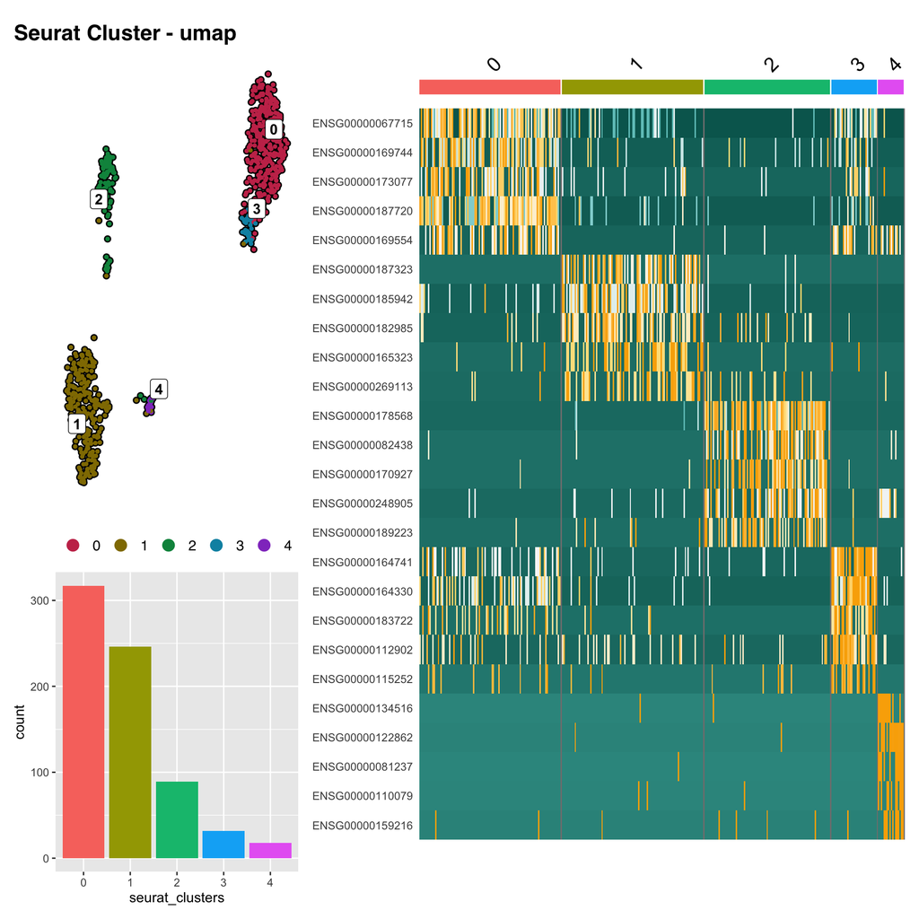

```r
# Select top 5 genes for heatmap plotting
s.markers <- na.omit(s.markers)
s.markers %>%
  group_by(group1) %>%
  top_n(n = 5, wt = log_fc) -> top5
# subset for plotting
cells <- WhichCells(srat, downsample = 100)
ss <- subset(srat, cells = cells)
ss <- ScaleData(ss, features = top5$feature)
p1 <- SCpubr::do_DimPlot(srat, reduction = "umap", group.by = "seurat_clusters", label = TRUE, repel = TRUE) + ggtitle("Seurat Cluster - umap")
p2 <- DoHeatmap(ss, features = top5$feature, cells = cells, group.by = "seurat_clusters") + NoLegend() +
  scale_fill_gradientn(colors = c("#01665e", "#35978f", "darkslategray3", "#f7f7f7", "#fee391", "#fec44f", "#F9AD03"))
p3 <- ggplot(srat@meta.data, aes(seurat_clusters, fill = seurat_clusters)) +
  geom_bar() +
  NoLegend()
common_title <- sprintf("Unsupervised clustering %s, %d cells", srat@meta.data$orig.ident[1], ncol(srat))
show((((p1 / p3) + plot_layout(heights = c(3, 2)) | p2)) + plot_layout(widths = c(1, 2)) + plot_layout(heights = c(3, 1)) + plot_annotation(title = common_title))
```

```r
DT::datatable(top5[, c(1, 9, 11, 12)],
  caption = ("top 5 marker genes"),
  extensions = "Buttons",
  options = list(
    dom = "Bfrtip",
    buttons = c("csv", "excel")
  )
)
```

|  | feature | group1 | gene_ids | gene_symbol |
| --- | --- | --- | --- | --- |
| 1 | ENSG00000067715 | 0 | ENSG00000067715 | SYT1 |
| 2 | ENSG00000169744 | 0 | ENSG00000169744 | LDB2 |
| 3 | ENSG00000173077 | 0 | ENSG00000173077 | DELEC1 |
| 4 | ENSG00000187720 | 0 | ENSG00000187720 | THSD4 |
| 5 | ENSG00000169554 | 0 | ENSG00000169554 | ZEB2 |
| 6 | ENSG00000187323 | 1 | ENSG00000187323 | DCC |
| 7 | ENSG00000185942 | 1 | ENSG00000185942 | NKAIN3 |
| 8 | ENSG00000182985 | 1 | ENSG00000182985 | CADM1 |
| 9 | ENSG00000165323 | 1 | ENSG00000165323 | FAT3 |
| 10 | ENSG00000269113 | 1 | ENSG00000269113 | TRABD2B |

[output cut: 15 more lines]

### Enrichment analysis of marker genes

Here we perform enrichment analysis of the marker genes found in the previous section for each Seurat cluster.

We defined as universe/background all the genes expressed in the dataset, meaning the rownames of the Seurat object.

- the hallmark gene sets are coherently expressed signatures derived by aggregating many `MSigDB` gene sets to represent well-defined biological states or processes.
- the C3 : regulatory target gene sets based on gene target predictions for microRNA seed sequences and predicted transcription factor binding sites.
- the C8 : cell type signature gene sets curated from cluster markers identified in single-cell sequencing studies of human tissue.

We used `clusterProfiler::enricher()` to perform enrichment analysis.

```r
# define background genes = universe for enrichment
background <- rownames(srat)
# Define gene signature per cluster
signatures <- list()
for (i in unique(s.markers$group1)) {
  signatures[[paste0("cluster ", i)]] <- s.markers$feature[s.markers$group1 == i]
}
```

#### Hallmarks `MSigDB` gene sets

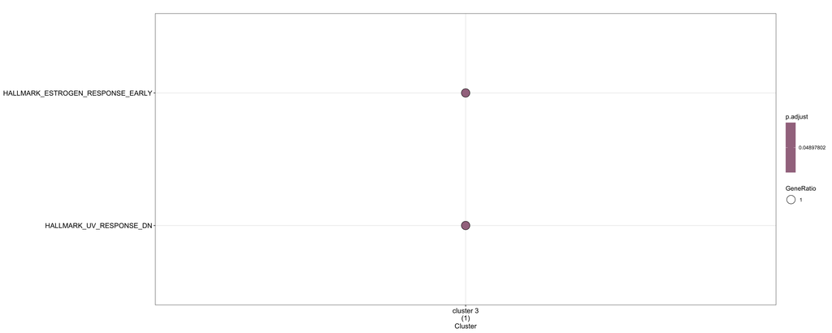

```r
Enrichment_plot(category = "H", signatures = signatures, background = background)
```

`EMT` signature should be enriched in stroma cluster. `E2F`/proliferation should be enriched in blastema cluster. `MYC(N)`, `TP53` must be enriched in blastema cluster.

#### C8 `MSigDB` cell type signature gene sets

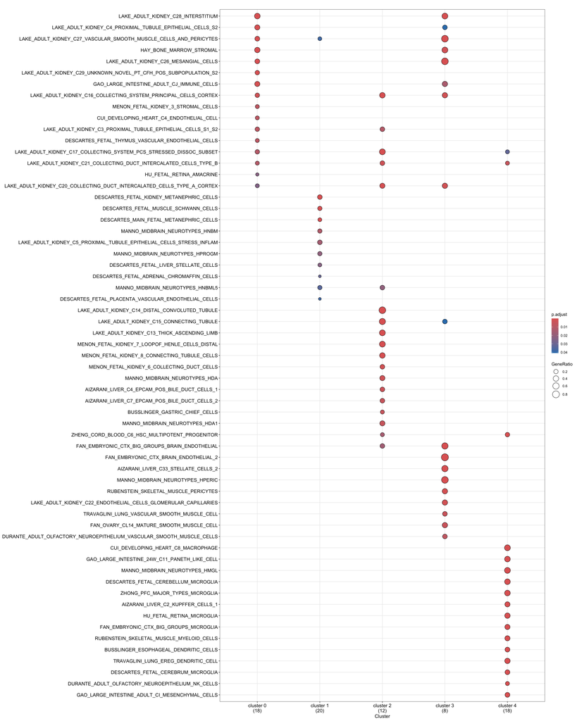

```r
Enrichment_plot(category = "C8", signatures = signatures, background = background)
```

The `MSigDB` C8 gene set is quite relevant for kidney and nephroblastoma annotations. Epithelial (cancer and normal) cells should be enriched in mature/adult kidney pathways while blastema cancer cells will show enrichment of fetal kidney development pathway / cap mesenchyme.

### Cell annotation

#### Introduction to the four annotation strategies

The use of the right reference is crucial for label transfer and annotation. It is recommended that the cell types in the reference is representative to the cell types to be annotated in the query.

Wilms tumors can contain up to three histologies that resemble fetal kidney: blastema, stroma, and epithelia. [[1](https://www.ncbi.nlm.nih.gov/books/NBK373356/), [2](https://www.ncbi.nlm.nih.gov/pmc/articles/PMC9915828/)]. Because of their histological similarity to fetal kidneys, Wilms tumors are thought to arise from developmental derangements in embryonic renal progenitors.

For these reasons, we expect Wilms tumor cells to map to fetal cells, especially fetal kidney cells.

Here, we investigate annotations resulting from 4 different strategies:

#### Annotation from `SingleR` (no cancer or kidney specific dataset)

```
## [1] "seurat_clusters"
```

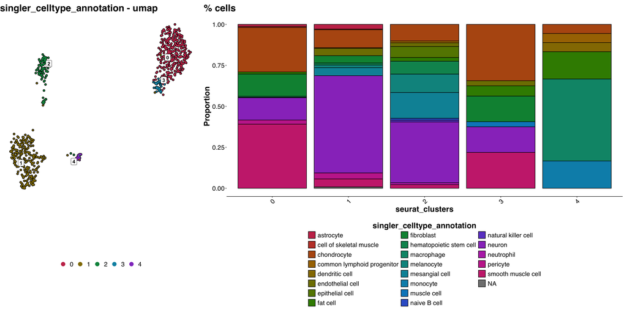

```r
visualize_metadata(srat, meta = "singler_celltype_annotation", group.by = "seurat_clusters")
```

#### Annotation from `CellAssign` (no cancer or kidney specific dataset)

```
## [1] "seurat_clusters"
```

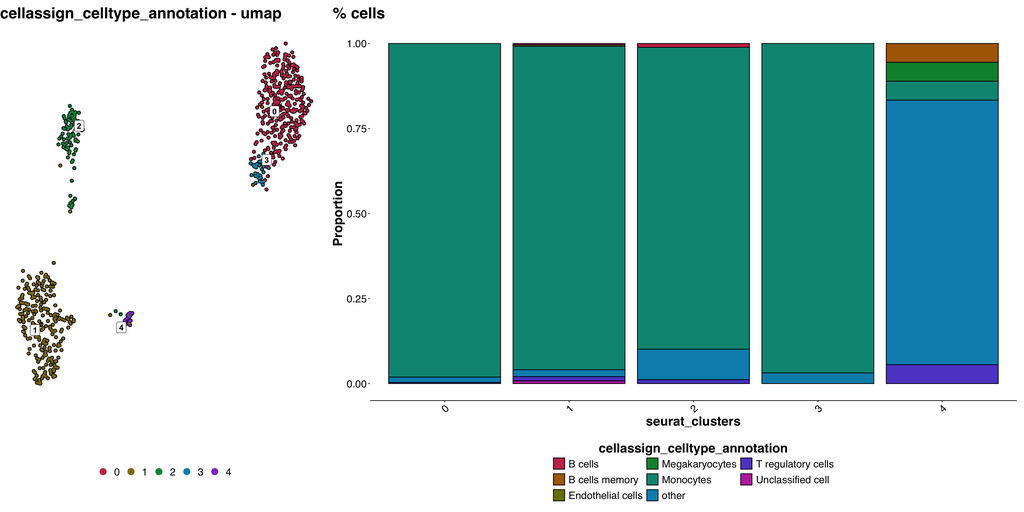

```r
visualize_metadata(srat, meta = "cellassign_celltype_annotation", group.by = "seurat_clusters")
```

#### Annotation from the fetal reference (Cao et al)

The fetal full reference (Cao et al.) provides three levels of annotations:

- `fetal_full_predicted.organ` is one of the 15 organs used for building the reference. We were nicely surprised that, for many of the samples, most of the cells from the Wilms tumor cohort mapped to fetal kidney cells.
- `fetal_full_predicted.annotation.l1` holds predicted cell type annotation
- `fetal_full_predicted.annotation.l2` holds the combination of the predicted organ and predicted cell type annotation

```
## [1] "seurat_clusters"
```

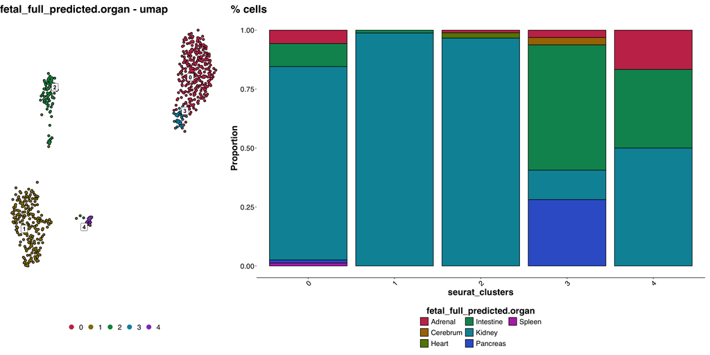

```r
visualize_metadata(srat, meta = "fetal_full_predicted.organ", group.by = "seurat_clusters")
```

```
## [1] "seurat_clusters"
```

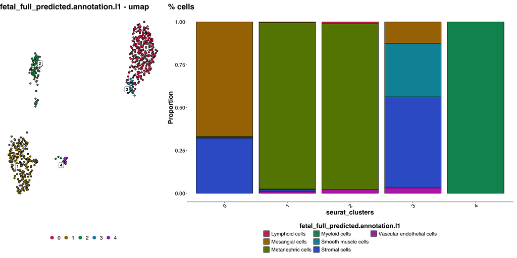

```r
visualize_metadata(srat, meta = "fetal_full_predicted.annotation.l1", group.by = "seurat_clusters")
```

```
## [1] "seurat_clusters"
```

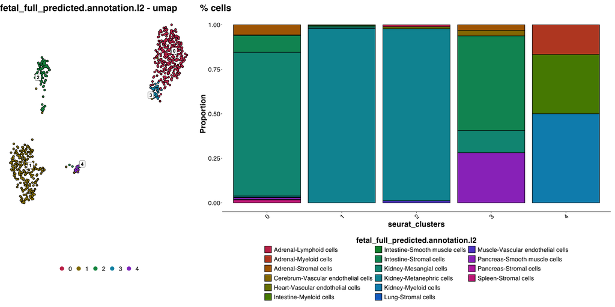

```r
visualize_metadata(srat, meta = "fetal_full_predicted.annotation.l2", group.by = "seurat_clusters")
```

#### Annotation from the kidney reference (Stewart et al)

The fetal kidney reference (Stewart et al.) provides two levels of annotations:

- `fetal_kidney_predicted.compartment` is one of the 4 main compartments composing a fetal kidney. We expect immune and endothelial cells to be healthy (non-cancerous) cells identified easily with high confidence. We expect stroma and fetal nephron compartment to contain both normal and malignant cells.
  - `immune` cells
  - `stroma` cells
  - `fetal_nephron` cells
  - `endothelial` cells
- `fetal_kidney_predicted.cell_type` holds predicted cell type annotations that details further the four compartments, as for example:
  - `immune` subtypes: myeloid cells, lymphocytes, …
  - `stroma` subtypes: mesenchymal stem cells, fibroblasts, …
  - `fetal_nephron` subtypes: podocytes, uteric bud, mesenchymal cells (that appear to be cap mesenchyme cells) …
  - `endothelial` cells

```
## [1] "seurat_clusters"
```

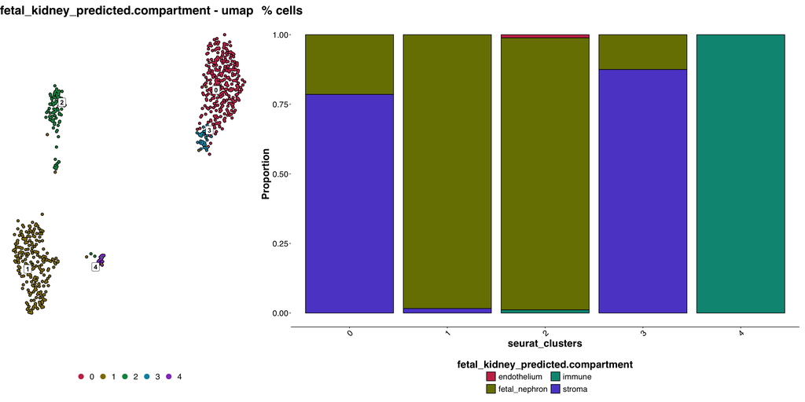

```r
visualize_metadata(srat, meta = "fetal_kidney_predicted.compartment", group.by = "seurat_clusters")
```

```
## [1] "seurat_clusters"
```

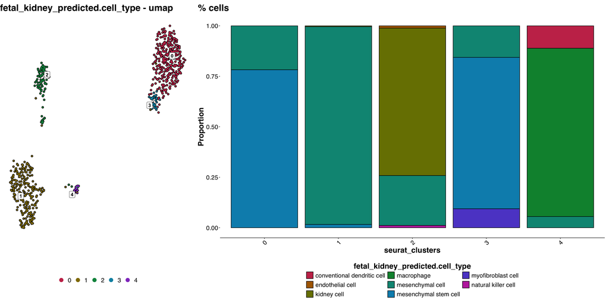

```r
visualize_metadata(srat, meta = "fetal_kidney_predicted.cell_type", group.by = "seurat_clusters")
```

### Compare annotations with marker genes

Here we evaluate with marker genes the identification of endothelial, immune cells and other cancer and non-cancerous sub-populations.

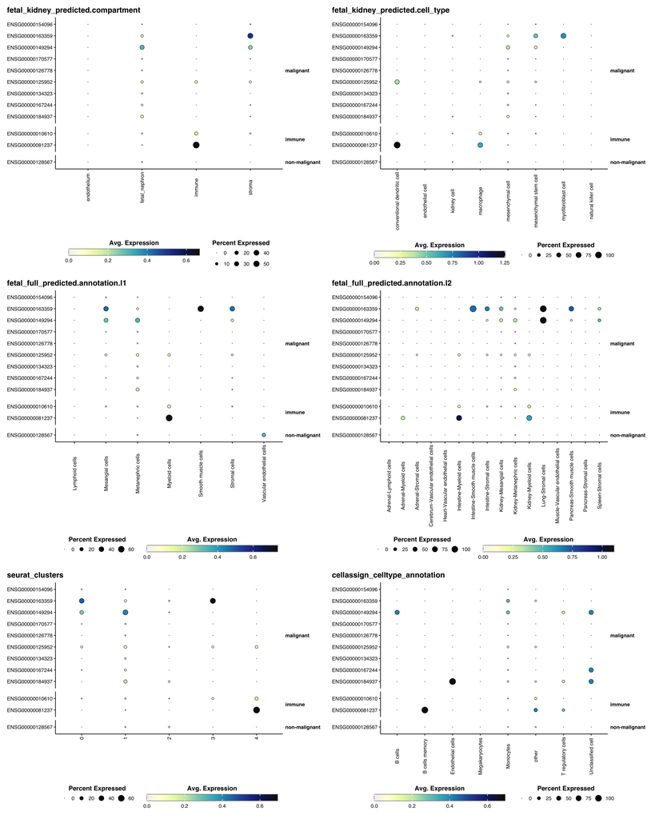

```r
markers <- list(
  "malignant" = CellType_metadata$ENSEMBL_ID[which(CellType_metadata$cell_class == "malignant")],
  "immune" = CellType_metadata$ENSEMBL_ID[which(CellType_metadata$cell_class == "immune")],
  "endothelium" = CellType_metadata$ENSEMBL_ID[which(CellType_metadata$cell_class == "endothelium")],
  "non-malignant" = CellType_metadata$ENSEMBL_ID[which(CellType_metadata$cell_class == "non-malignant")]
)

p1 <- SCpubr::do_DotPlot(
  sample = srat,
  group.by = "fetal_kidney_predicted.compartment",
  features = markers,
  axis.text.x.angle = 90,
  flip = TRUE,
  plot.title = "fetal_kidney_predicted.compartment"
)

p2 <- SCpubr::do_DotPlot(
  sample = srat,
  group.by = "fetal_kidney_predicted.cell_type",
  features = markers,
  axis.text.x.angle = 90,
  flip = TRUE,
  plot.title = "fetal_kidney_predicted.cell_type"
)


p3 <- SCpubr::do_DotPlot(
  sample = srat,
  group.by = "fetal_full_predicted.annotation.l1",
  features = markers,
  axis.text.x.angle = 90,
  flip = TRUE,
  plot.title = "fetal_full_predicted.annotation.l1"
)


p4 <- SCpubr::do_DotPlot(
  sample = srat,
  group.by = "fetal_full_predicted.annotation.l2",
  features = markers,
  axis.text.x.angle = 90,
  flip = TRUE,
  plot.title = "fetal_full_predicted.annotation.l2"
)

p5 <- SCpubr::do_DotPlot(
  sample = srat,
  group.by = "seurat_clusters",
  features = markers,
  axis.text.x.angle = 90,
  flip = TRUE,
  plot.title = "seurat_clusters"
)


p6 <- SCpubr::do_DotPlot(
  sample = srat,
  group.by = "cellassign_celltype_annotation",
  features = markers,
  axis.text.x.angle = 90,
  flip = TRUE,
  plot.title = "cellassign_celltype_annotation"
)

(p1 | p2) / (p3 | p4) / (p5 | p6)
```